# EVAR dose

Martin Hennessy

23/08/2020

# EVAR time and dose data

- A review of local practice of EVAR in terms of:
  1. Fluoroscopy time
  2. Acquisition time
  3. Total dose

## Operator & type

- EVAR adjuncts or alternatives included are:
  - Unilateral IIA embolisation
  - Bilateral IIA embolisation
  - IMA embolisation
  - Unilateral iliac branch
  - Bilateral iliac branch
  - EndoAnchors
  - Aorto-uni-iliac EVAR
  - Combinations thereof

### EVAR types

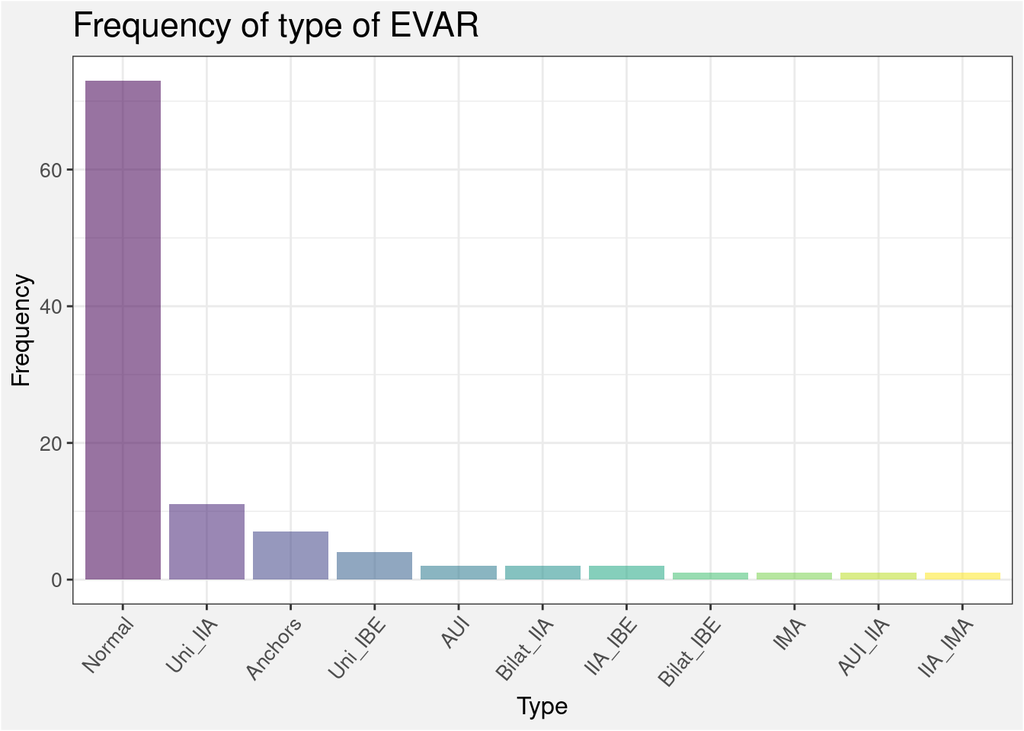

### Named EVAR consultant

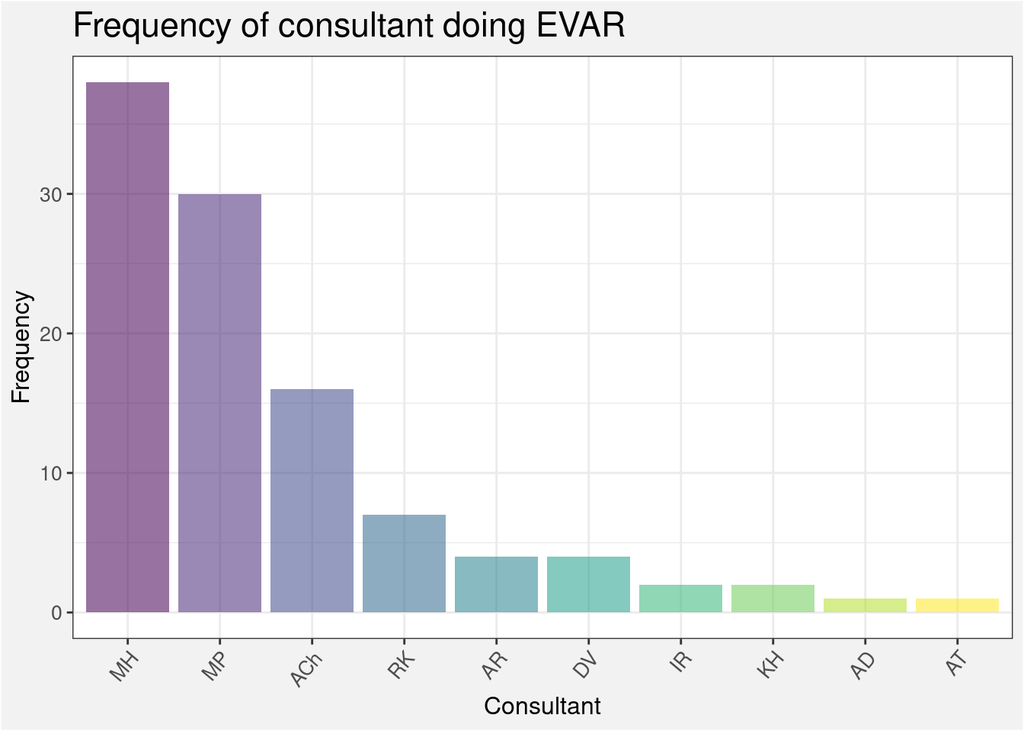

### Presence of registrar at EVARs

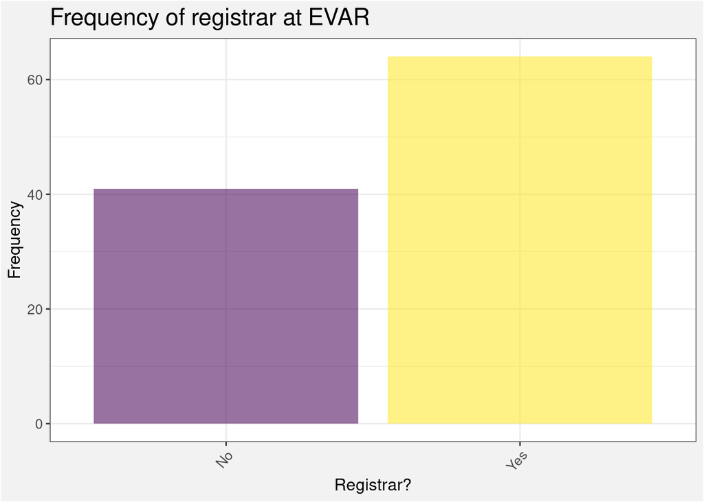

## Fluoroscopy time

### All EVAR

#### Histogram

- Histogram of fluoroscopy time for EVAR
- Vertical line is the median time (1215 seconds)
- (Data are not normally distributed (p = 1.629887910^{-8}))

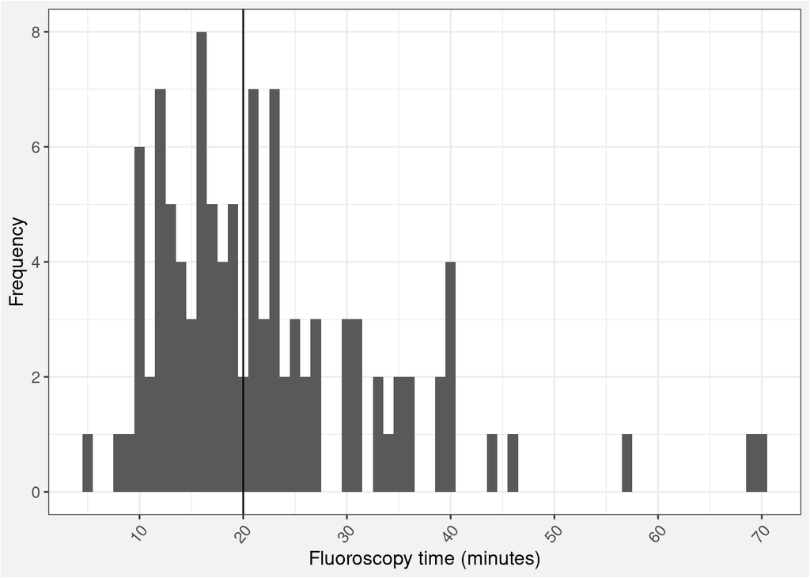

#### Boxplot

- The same data displayed as a boxplot

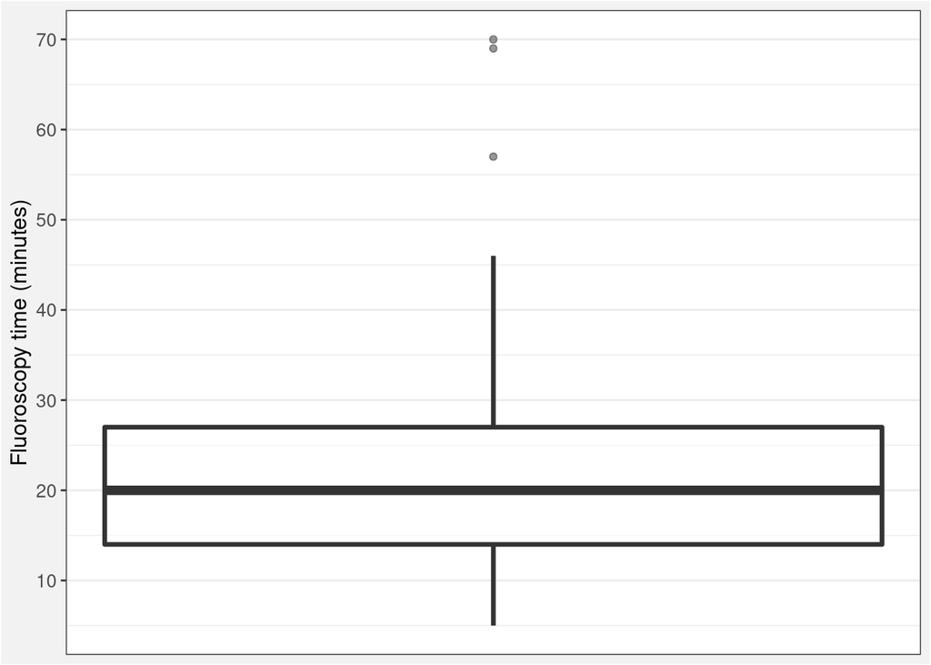

### ‘Standard’ vs EVAR with adjuncts

#### Histogram

- Histogram of fluoroscopy time for EVAR
- Vertical line is the median time for all EVAR

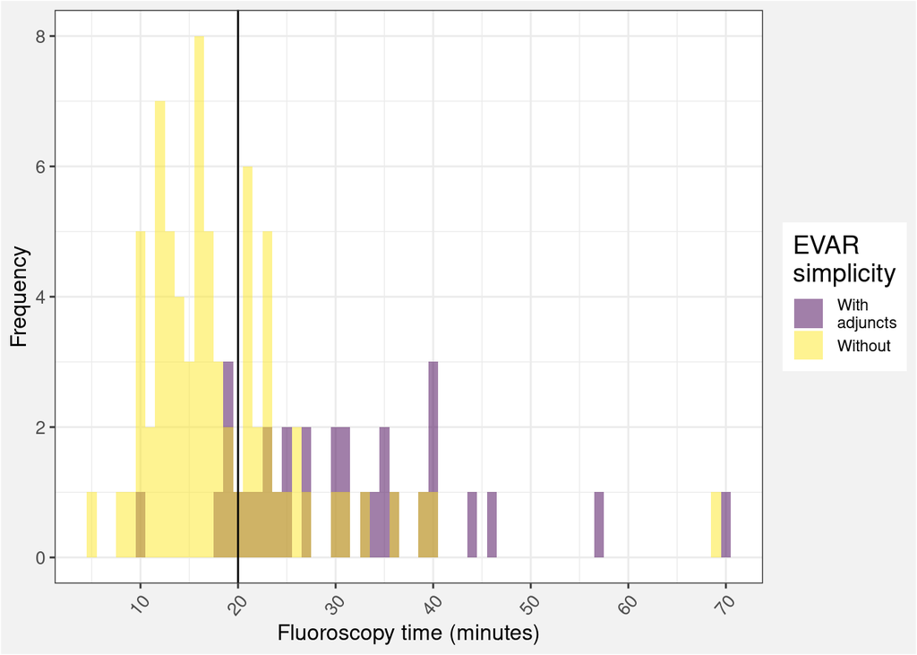

#### Boxplot

- The same data displayed as a boxplot

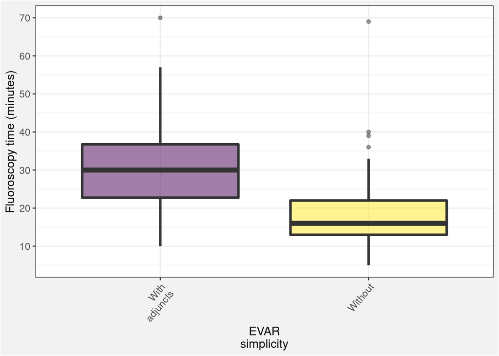